# Automatically generated Python scripts and Jupyter notebook

The library MoebInv can create annotatted Python scripts from existing figures--either created in C++ code or by mouse clicks in [GUI](https://sourceforge.net/projects/moebinv/files/binary/). The next section contains Jupyter notebook produced by [p2j (Python to Jupyter)](https://pypi.org/project/p2j/) from the automatically generated Python script. This script is included in the last section of this notebook as well.

Such scripts are produced by calls to `figure::write_python_script()` or its Python wrapper like this:

```
F.write_python_script("file-name.pt")
```

To evaluate the notebook we need to load libraries and optional magic extensions.

```python
from figure import *
%load_ext figure
```

## Figure: This is an illustration of the Nine point theorem.

We define new figure with the following point and cycle metrics:

```python
MyFig = figure(matrix([[-1, 0], [0, -1]]),\
matrix([[-1, 0], [0, -1]]))
```

### The figure description

```python
MyFig.info_write(\
"""
This is an illustration of the Nine point theorem.
For the triangle ABC defined by three given points A, B and C we construct:
* the feets of altitudes A_h, B_h and C_h;
* the midpoints of sides A_m, B_m and C_m;
* the midpoints A_d, B_d and C_d between the respective vertices and the point O of intersection of the altitudes.
All these nine points belong to the Euler circle p. Furthermore, p is tangent to three excircles v_a, v_b and v_c.
A user may play with this figure by moving points A, B and C around. It is even more intriguing to change the metrics of point and cycle spaces from the default elliptic to hyperbolic and parabolic!
""")
```

## Cycles in generation 0

The following cycles are proper point(s)

```python
C = MyFig.add_point([-1/5, -3/2], "C")
B = MyFig.add_point([1, 0], "B")
A = MyFig.add_point([-1, 0], "A")
```

The following cycle is defined by coefficients

```python
N = MyFig.add_cycle(cycle_data(0, matrix([[0, 0]]), 1), "N")
```

### Subfigure: Midpoint in cycle metric.

We will use the following subfigure

```python
MyFigSF1 = figure(matrix([[-1, 0], [0, -1]]),\
matrix([[-1, 0], [0, -1]])).freeze()
MyFigSF1.info_write(\
"""
Midpoint in cycle metric.
 For two points provided the figure returns their midpoint.
 For three given points A, B and N the subfigure produces
 such a point C on the cycle passing A, B and N,
 such that the cross-ratio of A, B, C, N is equal to 1.
 If N is infinity (the default value, if it is not supplied),
 then C is the midpoint between A and B as said above.
 More generally, for any two cycles A and B for N=infty
 figures returns the point between centres A and B
 which has equal tangential distance to A and B.
.
To use this subfigure provide cycles A, B and N in this order.
""")
variable002SF1 = MyFigSF1.add_cycle(cycle_data(0, matrix([[0, 0]]), 1), "variable002")
variable000SF1 = MyFigSF1.add_cycle(cycle_data(1, matrix([[1, 0]]), 1), "variable000")
variable001SF1 = MyFigSF1.add_cycle(cycle_data(1, matrix([[0, 0]]), 0), "variable001")
v4SF1 = MyFigSF1.add_cycle_rel([cycle_relation(variable000SF1, "orthogonal", True), cycle_relation(variable001SF1, "orthogonal", True), cycle_relation(variable002SF1, "orthogonal", True)], "v4")
v5SF1 = MyFigSF1.add_cycle_rel([cycle_relation(variable000SF1, "orthogonal", True), cycle_relation(variable001SF1, "orthogonal", True), cycle_relation(v4SF1, "orthogonal", True)], "v5")
v6SF1 = MyFigSF1.add_cycle_rel([cycle_relation(variable002SF1, "orthogonal", True), cycle_relation(v4SF1, "orthogonal", True), cycle_relation(v5SF1, "orthogonal", True)], "v6")
resultSF1 = realsymbol("result")
MyFigSF1.add_cycle_rel([cycle_relation(v4SF1, "orthogonal", True), cycle_relation(v6SF1, "orthogonal", True), cycle_relation(resultSF1, "orthogonal", False), cycle_relation(variable002SF1, "adifferent", True)], resultSF1)
```

```
<cginac.realsymbol at 0x7fb660581cb0>
```

## Cycles in generation 1

The following cycles are defined by the above subfigure(s)

```python
C_m = MyFig.add_subfigure(MyFigSF1, [A, B, N], "C_m")
MyFig.set_asy_style(C_m, "\nNE")
A_m = MyFig.add_subfigure(MyFigSF1, [B, C, N], "A_m")
MyFig.set_asy_style(A_m, "\nE")
B_m = MyFig.add_subfigure(MyFigSF1, [C, A, N], "B_m")
MyFig.set_asy_style(B_m, "\nNE")
```

The following cycles are defined by cycle relations

```python
b = MyFig.add_cycle_rel([cycle_relation(A, "orthogonal", True), cycle_relation(C, "orthogonal", True), cycle_relation(N, "orthogonal", True)], "b")
MyFig.set_asy_style(b, "rgb(0,0,.8)+1")
a = MyFig.add_cycle_rel([cycle_relation(B, "orthogonal", True), cycle_relation(C, "orthogonal", True), cycle_relation(N, "orthogonal", True)], "a")
MyFig.set_asy_style(a, "rgb(0,0,.8)+1")
c = MyFig.add_cycle_rel([cycle_relation(A, "orthogonal", True), cycle_relation(B, "orthogonal", True), cycle_relation(N, "orthogonal", True)], "c")
MyFig.set_asy_style(c, "\nNE")
```

## Cycles in generation 2

The following cycles are defined by cycle relations

```python
h_b = MyFig.add_cycle_rel([cycle_relation(B, "orthogonal", True), cycle_relation(N, "orthogonal", True), cycle_relation(b, "orthogonal", True)], "h_b")
MyFig.set_asy_style(h_b, "dashed")
v_a = MyFig.add_cycle_rel([cycle_relation(a, "tangent_o", True), cycle_relation(b, "tangent_i", True), cycle_relation(c, "tangent_i", True)], "v_a")
MyFig.set_asy_style(v_a, "rgb(0.8,0,0)+.5\nSE")
v_c = MyFig.add_cycle_rel([cycle_relation(a, "tangent_i", True), cycle_relation(b, "tangent_i", True), cycle_relation(c, "tangent_o", True)], "v_c")
MyFig.set_asy_style(v_c, "rgb(0.8,0,0)+.5")
h_c = MyFig.add_cycle_rel([cycle_relation(C, "orthogonal", True), cycle_relation(N, "orthogonal", True), cycle_relation(c, "orthogonal", True)], "h_c")
MyFig.set_asy_style(h_c, "dashed")
v_b = MyFig.add_cycle_rel([cycle_relation(a, "tangent_i", True), cycle_relation(b, "tangent_o", True), cycle_relation(c, "tangent_i", True)], "v_b")
MyFig.set_asy_style(v_b, "rgb(0.8,0,0)+.5")
h_a = MyFig.add_cycle_rel([cycle_relation(A, "orthogonal", True), cycle_relation(N, "orthogonal", True), cycle_relation(a, "orthogonal", True)], "h_a")
MyFig.set_asy_style(h_a, "dashed")
```

## Cycles in generation 3

The following cycles are defined by cycle relations

```python
A_h = realsymbol("A_h")
MyFig.add_cycle_rel([cycle_relation(a, "orthogonal", True), cycle_relation(h_a, "orthogonal", True), cycle_relation(A_h, "orthogonal", True), cycle_relation(N, "adifferent", True)], A_h)
O = realsymbol("O")
MyFig.add_cycle_rel([cycle_relation(h_a, "orthogonal", True), cycle_relation(h_b, "orthogonal", True), cycle_relation(O, "orthogonal", True), cycle_relation(N, "adifferent", True)], O)
B_h = realsymbol("B_h")
MyFig.add_cycle_rel([cycle_relation(b, "orthogonal", True), cycle_relation(h_b, "orthogonal", True), cycle_relation(N, "adifferent", True), cycle_relation(B_h, "orthogonal", True)], B_h)
MyFig.set_asy_style(B_h, "\nS")
C_h = realsymbol("C_h")
MyFig.add_cycle_rel([cycle_relation(N, "adifferent", True), cycle_relation(c, "orthogonal", True), cycle_relation(h_c, "orthogonal", True), cycle_relation(C_h, "orthogonal", True)], C_h)
MyFig.set_asy_style(C_h, "\nNW")
```

## Cycles in generation 4

The following cycles are defined by the above subfigure(s)

```python
A_d = MyFig.add_subfigure(MyFigSF1, [O, A, N], "A_d")
MyFig.set_asy_style(A_d, "\nE")
C_d = MyFig.add_subfigure(MyFigSF1, [C, O, N], "C_d")
B_d = MyFig.add_subfigure(MyFigSF1, [B, O, N], "B_d")
MyFig.set_asy_style(B_d, "\nNE")
```

The following cycle is defined by cycle relations

```python
p = MyFig.add_cycle_rel([cycle_relation(A_h, "orthogonal", True), cycle_relation(B_h, "orthogonal", True), cycle_relation(C_h, "orthogonal", True)], "p")
MyFig.set_asy_style(p, "rgb(0,.8,0)+1\nSW")
```

## The automatically generated Python script

The above notebook is produced by [p2j (Python to Jupyter)](https://pypi.org/project/p2j/) utility from the Python script provided below. It is included ``as-is'' after its generaion by the library.

```python
# ## Figure: This is an illustration of the Nine point theorem.
# We define new figure with the following point and cycle metrics:
MyFig = figure(matrix([[-1, 0], [0, -1]]),\
matrix([[-1, 0], [0, -1]]))

# ### The figure description
MyFig.info_write(\
"""
This is an illustration of the Nine point theorem.
For the triangle ABC defined by three given points A, B and C we construct:
* the feets of altitudes A_h, B_h and C_h;
* the midpoints of sides A_m, B_m and C_m;
* the midpoints A_d, B_d and C_d between the respective vertices and the point O of intersection of the altitudes.
All these nine points belong to the Euler circle p. Furthermore, p is tangent to three excircles v_a, v_b and v_c.
A user may play with this figure by moving points A, B and C around. It is even more intriguing to change the metrics of point and cycle spaces from the default elliptic to hyperbolic and parabolic!
""")

# ## Cycles in generation 0
# The following cycles are proper point(s)
C = MyFig.add_point([-1/5, -3/2], "C")
B = MyFig.add_point([1, 0], "B")
A = MyFig.add_point([-1, 0], "A")

# The following cycle is defined by coefficients
N = MyFig.add_cycle(cycle_data(0, matrix([[0, 0]]), 1), "N")


# ### Subfigure: Midpoint in cycle metric.
# We will use the following subfigure
MyFigSF1 = figure(matrix([[-1, 0], [0, -1]]),\
matrix([[-1, 0], [0, -1]])).freeze()
MyFigSF1.info_write(\
"""
Midpoint in cycle metric.
 For two points provided the figure returns their midpoint.
 For three given points A, B and N the subfigure produces
 such a point C on the cycle passing A, B and N,
 such that the cross-ratio of A, B, C, N is equal to 1.
 If N is infinity (the default value, if it is not supplied),
 then C is the midpoint between A and B as said above.
 More generally, for any two cycles A and B for N=infty
 figures returns the point between centres A and B
 which has equal tangential distance to A and B.
.
To use this subfigure provide cycles A, B and N in this order.
""")
variable002SF1 = MyFigSF1.add_cycle(cycle_data(0, matrix([[0, 0]]), 1), "variable002")
variable000SF1 = MyFigSF1.add_cycle(cycle_data(1, matrix([[1, 0]]), 1), "variable000")
variable001SF1 = MyFigSF1.add_cycle(cycle_data(1, matrix([[0, 0]]), 0), "variable001")
v4SF1 = MyFigSF1.add_cycle_rel([cycle_relation(variable000SF1, "orthogonal", True), cycle_relation(variable001SF1, "orthogonal", True), cycle_relation(variable002SF1, "orthogonal", True)], "v4")
v5SF1 = MyFigSF1.add_cycle_rel([cycle_relation(variable000SF1, "orthogonal", True), cycle_relation(variable001SF1, "orthogonal", True), cycle_relation(v4SF1, "orthogonal", True)], "v5")
v6SF1 = MyFigSF1.add_cycle_rel([cycle_relation(variable002SF1, "orthogonal", True), cycle_relation(v4SF1, "orthogonal", True), cycle_relation(v5SF1, "orthogonal", True)], "v6")
resultSF1 = realsymbol("result")
MyFigSF1.add_cycle_rel([cycle_relation(v4SF1, "orthogonal", True), cycle_relation(v6SF1, "orthogonal", True), cycle_relation(resultSF1, "orthogonal", False), cycle_relation(variable002SF1, "adifferent", True)], resultSF1)




# ## Cycles in generation 1
# The following cycles are defined by the above subfigure(s)
C_m = MyFig.add_subfigure(MyFigSF1, [A, B, N], "C_m")
MyFig.set_asy_style(C_m, "\nNE")
A_m = MyFig.add_subfigure(MyFigSF1, [B, C, N], "A_m")
MyFig.set_asy_style(A_m, "\nE")
B_m = MyFig.add_subfigure(MyFigSF1, [C, A, N], "B_m")
MyFig.set_asy_style(B_m, "\nNE")

# The following cycles are defined by cycle relations
b = MyFig.add_cycle_rel([cycle_relation(A, "orthogonal", True), cycle_relation(C, "orthogonal", True), cycle_relation(N, "orthogonal", True)], "b")
MyFig.set_asy_style(b, "rgb(0,0,.8)+1")
a = MyFig.add_cycle_rel([cycle_relation(B, "orthogonal", True), cycle_relation(C, "orthogonal", True), cycle_relation(N, "orthogonal", True)], "a")
MyFig.set_asy_style(a, "rgb(0,0,.8)+1")
c = MyFig.add_cycle_rel([cycle_relation(A, "orthogonal", True), cycle_relation(B, "orthogonal", True), cycle_relation(N, "orthogonal", True)], "c")
MyFig.set_asy_style(c, "\nNE")


# ## Cycles in generation 2
# The following cycles are defined by cycle relations
h_b = MyFig.add_cycle_rel([cycle_relation(B, "orthogonal", True), cycle_relation(N, "orthogonal", True), cycle_relation(b, "orthogonal", True)], "h_b")
MyFig.set_asy_style(h_b, "dashed")
v_a = MyFig.add_cycle_rel([cycle_relation(a, "tangent_o", True), cycle_relation(b, "tangent_i", True), cycle_relation(c, "tangent_i", True)], "v_a")
MyFig.set_asy_style(v_a, "rgb(0.8,0,0)+.5\nSE")
v_c = MyFig.add_cycle_rel([cycle_relation(a, "tangent_i", True), cycle_relation(b, "tangent_i", True), cycle_relation(c, "tangent_o", True)], "v_c")
MyFig.set_asy_style(v_c, "rgb(0.8,0,0)+.5")
h_c = MyFig.add_cycle_rel([cycle_relation(C, "orthogonal", True), cycle_relation(N, "orthogonal", True), cycle_relation(c, "orthogonal", True)], "h_c")
MyFig.set_asy_style(h_c, "dashed")
v_b = MyFig.add_cycle_rel([cycle_relation(a, "tangent_i", True), cycle_relation(b, "tangent_o", True), cycle_relation(c, "tangent_i", True)], "v_b")
MyFig.set_asy_style(v_b, "rgb(0.8,0,0)+.5")
h_a = MyFig.add_cycle_rel([cycle_relation(A, "orthogonal", True), cycle_relation(N, "orthogonal", True), cycle_relation(a, "orthogonal", True)], "h_a")
MyFig.set_asy_style(h_a, "dashed")


# ## Cycles in generation 3
# The following cycles are defined by cycle relations
A_h = realsymbol("A_h")
MyFig.add_cycle_rel([cycle_relation(a, "orthogonal", True), cycle_relation(h_a, "orthogonal", True), cycle_relation(A_h, "orthogonal", True), cycle_relation(N, "adifferent", True)], A_h)
O = realsymbol("O")
MyFig.add_cycle_rel([cycle_relation(h_a, "orthogonal", True), cycle_relation(h_b, "orthogonal", True), cycle_relation(O, "orthogonal", True), cycle_relation(N, "adifferent", True)], O)
B_h = realsymbol("B_h")
MyFig.add_cycle_rel([cycle_relation(b, "orthogonal", True), cycle_relation(h_b, "orthogonal", True), cycle_relation(N, "adifferent", True), cycle_relation(B_h, "orthogonal", True)], B_h)
MyFig.set_asy_style(B_h, "\nS")
C_h = realsymbol("C_h")
MyFig.add_cycle_rel([cycle_relation(N, "adifferent", True), cycle_relation(c, "orthogonal", True), cycle_relation(h_c, "orthogonal", True), cycle_relation(C_h, "orthogonal", True)], C_h)
MyFig.set_asy_style(C_h, "\nNW")


# ## Cycles in generation 4
# The following cycles are defined by the above subfigure(s)
A_d = MyFig.add_subfigure(MyFigSF1, [O, A, N], "A_d")
MyFig.set_asy_style(A_d, "\nE")
C_d = MyFig.add_subfigure(MyFigSF1, [C, O, N], "C_d")
B_d = MyFig.add_subfigure(MyFigSF1, [B, O, N], "B_d")
MyFig.set_asy_style(B_d, "\nNE")

# The following cycle is defined by cycle relations
p = MyFig.add_cycle_rel([cycle_relation(A_h, "orthogonal", True), cycle_relation(B_h, "orthogonal", True), cycle_relation(C_h, "orthogonal", True)], "p")
MyFig.set_asy_style(p, "rgb(0,.8,0)+1\nSW")
```

Finally, we visualise the produced figure to compare it with the original one from the [notebook](https://github.com/vvkisil/MoebInv-notebooks/blob/master/Introduction/Nine_point_theorem.ipynb):

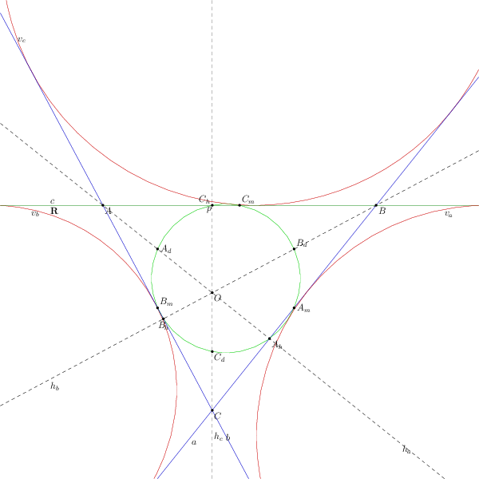

```python
%asy_write(MyFig,600,-1.75,1.75,-2,1.5,"test-9p")
```